# Methods for Analyzing Large Spatial Data: A Review and Comparison

## What’s so hard about this problem anyways?

## Scaling!

\[X \sim \operatorname{MVN}(\boldsymbol{\mu}, \boldsymbol{\Sigma})\]

\[f(\mathbf{x}) = \left(\frac{1}{\sqrt{2 \pi}}\right)^{n} \lvert \boldsymbol{\Sigma}\rvert^{-1/2} \exp \left(-{\frac {1}{2}}({\mathbf {x} }-{\boldsymbol {\mu }})^{\mathrm {T} }{\boldsymbol {\Sigma }}^{-1}({\mathbf {x} }-{\boldsymbol {\mu }})\right)\]

- \(\mathcal{O}(n^3)\) operations
- \(\mathcal{O}(n^2)\) storage

## Strategies: Rank reduction

- Fixed Rank Kriging
- Lattice Kriging
- **Predictive Processes**
- Multiresolution Approximations

## Strategies: Markovianity/sparsity

- Lattice Kriging
- Covariance Tapering
- Multiresolution Approximations
- Nearest Neighbor Gaussian Processes
- **Stochastic Partial Differential Equation Approach**

## Strategies: Approximate likelihood/subsampling

- Spatial Partitioning
- Covariance Tapering
- Nearest Neighbor Gaussian Processes
- Metakriging
- Locally Approximate Gaussian Processes
- Spatial Partitioning
- Multiresolution Approximation
- Metakriging
- Gapfill

## Methods

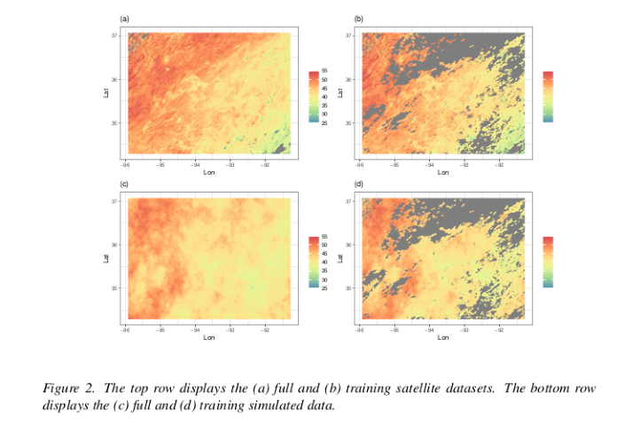

## Results: Simulated data

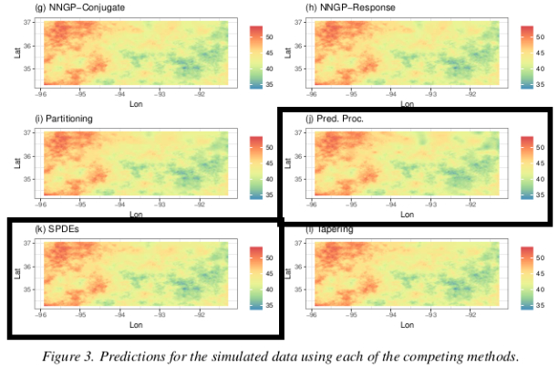

## Results: Simulated data

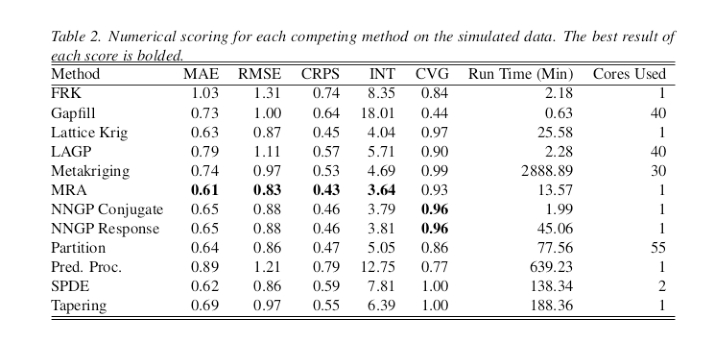

## Results: Satellite data

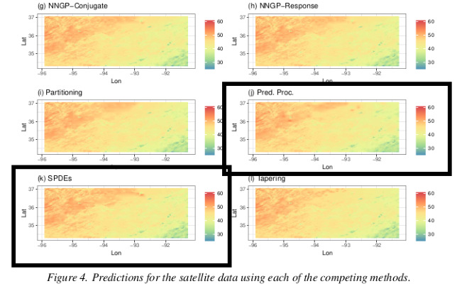

## Results: Satellite data

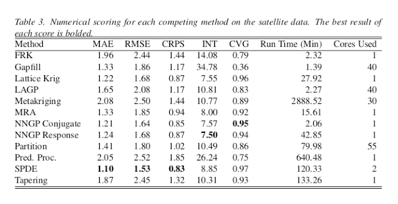

## Our methods

## Approximations

This quarter, we were interested in software for performing Bayesian inference in spatial problems.

|  | GRF | Posterior |
| --- | --- | --- |
| Predictive Process (`spBayes`) | Rank-reduced | MCMC |
| SPDE/INLA (`INLA`) | SPDE Approximation | INLA |
| Stan | Roll-your-own | MCMC |

## Using Stan for spatial statistics

If you:

1. can write down the statistical model;
2. have a differentiable log-posterior density;

you can probably code it in Stan (it’s Turing complete)!

- [Adding a GP kernel to Stan](https://github.com/stan-dev/stan/wiki/Adding-a-Gaussian-Process-Covariance-Function)
- [Gaussian Predictive Process in Stan](http://mbjoseph.github.io/2016/08/14/gpp.html)
- [Nearest Neighbor GP in Stan (in development)](http://discourse.mc-stan.org/t/case-study-nngp-based-models-in-stan/2575)
- Who wants to code up the SPDE model in Stan???

## Further reading

- [Original ArXiv paper](https://arxiv.org/abs/1710.05013)
- [Github Code Repository](https://github.com/finnlindgren/heatoncomparison/tree/master/Code)
- [Daniel Simpson’s comments](http://andrewgelman.com/2017/10/20/barry-gibb-came-fourth-barry-gibb-look-alike-contest/)